# 공간통계를 위한 데이터 사이언스

좌표계 변환

[Tidyverse Korea](https://www.facebook.com/groups/tidyverse/)

Tidyverse Korea

2020-09-06

# 1 대한민국 좌표계[^1]

- 좌표계(CRS) 참고
- [spatial reference list 검색 웹사이트](https://spatialreference.org/ref/)

# 2 주소와 좌표 데이터

주출입구의 좌표정보가 결합된 [위치정보요약DB](https://www.juso.go.kr/addrlink/addressBuildDevNew.do?menu=geodata)를 행정안전부 주소정책과에서 제공하고 있다.

## 2.1 위치정보요약 매뉴얼

위치정보요약 매뉴얼에 제공되는 주출입구 위치는 **GRS80 UTM-K** 좌표 기준으로 제공되고 있다. 따라서, 공간정보 시각화를 위해서 좌표를 조정해야 정확한 위치를 파악할 수 있게 된다.

```r
library(tidyverse)
library(slickR)
library(pdftools)

manual_pdf <- pdf_convert("data/location_db/location_DB_manual.pdf",format = 'png',verbose = FALSE)

fs::file_move("location_DB_manual_1.png", "fig/")
fs::file_move("location_DB_manual_2.png", "fig/")
fs::file_move("location_DB_manual_3.png", "fig/")

manual_pdf_df <- tibble(page = glue::glue("fig/{manual_pdf}") )

slickR(manual_pdf_df$page, height = 600)
```

[interactive chart not shown]

## 2.2 위치 데이터

먼저, 매뉴얼 PDF에서 스키마를 참조하여 필드명을 추출한다.

```r
## 칼럼명
library(tabulizer)
# locate_areas("data/location_db/location_DB_manual.pdf", pages = 2)

loc_fieldname <- extract_tables("data/location_db/location_DB_manual.pdf",
               pages = 2,
               guess = FALSE,
               area = list(c(206.42936,  27.64179, 647.18799, 524.37831)),
               encoding = "UTF-8")

loc_fieldname_vec <- loc_fieldname[[1]] %>%
  as.data.frame() %>%
  select(V2) %>%
  slice(4:25) %>%
  filter(!is.na(V2), V2!="") %>%
  mutate(변수명 = str_extract(V2, "[가-힣a-zA-Z]+")) %>%
  pull(변수명)

loc_fieldname_vec
```

```
 [1] "시군구코드"     "출입구일련번호" "법정동코드"     "시도명"
 [5] "시군구명"       "읍면동명"       "도로명코드"     "도로명"
 [9] "지하여부"       "건물본번"       "건물부번"       "건물명"
[13] "우편번호"       "건물용도분류"   "건물군여부"     "관할행정동"
[17] "X좌표"          "Y좌표"
```

앞서 추출한 칼럼명을 위치정보요약DB 본파일에 입혀 후속 작업을 진행할 수 있도록 데이터프레임을 제작한다.

```r
loc_dat <- read_delim("data/location_db/entrc_mod.txt", col_names = FALSE, delim = "|")

## 인코딩 변환: CP949 --> UTF-8
loc_df <- loc_dat %>%
  mutate_all(iconv, from = "CP949", to = "UTF-8") %>%
  set_names(c(loc_fieldname_vec, "이동사유코드")) %>%
  na.omit() %>%
  mutate(X좌표 = as.numeric(X좌표),
         Y좌표 = as.numeric(Y좌표))

loc_df %>%
  sample_n(10) %>%
  DT::datatable()
```

|  | 시군구코드 | 출입구일련번호 | 법정동코드 | 시도명 | 시군구명 | 읍면동명 | 도로명코드 | 도로명 | 지하여부 | 건물본번 | 건물부번 | 건물명 | 우편번호 | 건물용도분류 | 건물군여부 | 관할행정동 | X좌표 | Y좌표 | 이동사유코드 |
| --- | --- | --- | --- | --- | --- | --- | --- | --- | --- | --- | --- | --- | --- | --- | --- | --- | --- | --- | --- |
| 1 | 41480 | 44796 | 4148012200 | 경기도 | 파주시 | 와동동 | 414803206106 | 가람로 | 0 | 20 | 0 | 가람마을1단지벽산한라 아파트 | 10895 | 근린생활시설 | 0 | 운정1동 | 934119.41372 | 1970721.853793 | 34 |
| 2 | 48250 | 70789 | 4825010700 | 경상남도 | 김해시 | 삼계동 | 482503335072 | 삼계로 | 0 | 132 | 0 | 김해시민체육공원 | 50832 | 문화/관광/레저시설 | 1 | 북부동 | 1125155.245846 | 1697230.607898 | 31 |
| 3 | 11680 | 18506 | 1168010800 | 서울특별시 | 강남구 | 논현동 | 116803121022 | 논현로 | 0 | 645 | 0 | 엘리에나호텔 | 06116 | 문화/관광/레저시설 | 0 | 논현1동 | 958618.987145 | 1945880.105796 | 34 |
| 4 | 47900 | 15548 | 4790025000 | 경상북도 | 예천군 | 예천읍 | 479004769101 | 땅골못길 | 0 | 19 | 0 | 메이트모텔 | 36818 | 근린생활시설,숙박시설 | 1 | 예천읍 | 1087726.437778 | 1851846.119413 | 34 |
| 5 | 11620 | 14308 | 1162010100 | 서울특별시 | 관악구 | 봉천동 | 116204160677 | 장군봉5길 | 0 | 40 | 0 | 더프라임 | 08784 | 주택 | 0 | 청룡동 | 950604.37285 | 1942494.323732 | 34 |
| 6 | 50110 | 62118 | 5011025900 | 제주특별자치도 | 제주시 | 조천읍 | 501103349238 | 중산간동로 | 0 | 737 | 7 | 제일농장 | 63343 | 공장/창고시설 | 0 | 조천읍 | 922216.71667 | 1500812.690715 | 34 |
| 7 | 11110 | 15690 | 1111013500 | 서울특별시 | 종로구 | 관철동 | 111104100307 | 종로12길 | 0 | 15 | 0 | 종로코아 | 03190 | 근린생활시설 | 0 | 종로1.2.3.4가동 | 954596.238797 | 1952346.503719 | 34 |
| 8 | 29155 | 8331 | 2915510500 | 광주광역시 | 남구 | 백운동 | 291554283233 | 독립로15번길 | 0 | 6 | 0 | 신신모텔 | 61656 | 숙박시설 | 0 | 백운2동 | 945411.317997 | 1682375.295234 | 63 |
| 9 | 47190 | 61021 | 4719011100 | 경상북도 | 구미시 | 신평동 | 471904724608 | 야은로43길 | 0 | 13 | 0 | 성원 상떼빌 | 39239 | 주택 | 1 | 신평1동 | 1077539.681468 | 1792370.887472 | 34 |
| 10 | 11710 | 35137 | 1171010800 | 서울특별시 | 송파구 | 문정동 | 117104853403 | 법원로8길 | 0 | 9 | 0 | 문정 청림빌딩 | 05855 | 업무시설 | 0 | 문정2동 | 966563.441635 | 1942856.937137 | 31 |

## 2.3 좌표계 변환

```r
library(sf)

## KATEC --> UTM-K
loc_katec_sf <- loc_df %>%
  st_as_sf(coords = c("X좌표", "Y좌표"), crs = 5179 )

st_crs(loc_katec_sf)
```

```
Coordinate Reference System:
  User input: EPSG:5179
  wkt:
PROJCRS["Korea 2000 / Unified CS",
    BASEGEOGCRS["Korea 2000",
        DATUM["Geocentric datum of Korea",
            ELLIPSOID["GRS 1980",6378137,298.257222101,
                LENGTHUNIT["metre",1]]],
        PRIMEM["Greenwich",0,
            ANGLEUNIT["degree",0.0174532925199433]],
        ID["EPSG",4737]],
    CONVERSION["Korea Unified Belt",
        METHOD["Transverse Mercator",
            ID["EPSG",9807]],
        PARAMETER["Latitude of natural origin",38,
            ANGLEUNIT["degree",0.0174532925199433],
            ID["EPSG",8801]],
        PARAMETER["Longitude of natural origin",127.5,
            ANGLEUNIT["degree",0.0174532925199433],
            ID["EPSG",8802]],
        PARAMETER["Scale factor at natural origin",0.9996,
            SCALEUNIT["unity",1],
            ID["EPSG",8805]],
        PARAMETER["False easting",1000000,
            LENGTHUNIT["metre",1],
            ID["EPSG",8806]],
        PARAMETER["False northing",2000000,
            LENGTHUNIT["metre",1],
            ID["EPSG",8807]]],
    CS[Cartesian,2],
        AXIS["northing (X)",north,
            ORDER[1],
            LENGTHUNIT["metre",1]],
        AXIS["easting (Y)",east,
            ORDER[2],
            LENGTHUNIT["metre",1]],
    USAGE[
        SCOPE["unknown"],
        AREA["Korea, Republic of (South Korea)"],
        BBOX[28.6,122.71,40.27,134.28]],
    ID["EPSG",5179]]
```

```r
loc_katec_sf %>%
  select(법정동코드, 시도명, 시군구명, 읍면동명, geometry)
```

```
Simple feature collection with 3233 features and 4 fields
geometry type:  POINT
dimension:      XY
bbox:           xmin: 751429.2 ymin: 1473720 xmax: 1298827 ymax: 2039781
projected CRS:  Korea 2000 / Unified CS
# A tibble: 3,233 x 5
   법정동코드 시도명     시군구명 읍면동명           geometry
   <chr>      <chr>      <chr>    <chr>           <POINT [m]>
 1 1121510300 서울특별시 광진구   구의동   (963751.3 1949323)
 2 1121510300 서울특별시 광진구   구의동   (963453.8 1949733)
 3 1123010900 서울특별시 동대문구 휘경동   (960651.1 1954445)
 4 1130510300 서울특별시 강북구   수유동   (957250.6 1959784)
 5 1135010500 서울특별시 노원구   상계동     (960882 1964242)
 6 1141011900 서울특별시 서대문구 북가좌동   (948710 1953846)
 7 1141011800 서울특별시 서대문구 홍은동   (949465.2 1953500)
 8 1147010200 서울특별시 양천구   목동     (944287.1 1949767)
 9 1150010500 서울특별시 강서구   마곡동   (941536.5 1951791)
10 1150010800 서울특별시 강서구   공항동   (939428.6 1950859)
# ... with 3,223 more rows
```

```r
## WGS84 --> GPS
loc_gps_sf <- loc_df %>%
  st_as_sf(coords = c("X좌표", "Y좌표"), crs = 4326  )

st_crs(loc_gps_sf)
```

```
Coordinate Reference System:
  User input: EPSG:4326
  wkt:
GEOGCRS["WGS 84",
    DATUM["World Geodetic System 1984",
        ELLIPSOID["WGS 84",6378137,298.257223563,
            LENGTHUNIT["metre",1]]],
    PRIMEM["Greenwich",0,
        ANGLEUNIT["degree",0.0174532925199433]],
    CS[ellipsoidal,2],
        AXIS["geodetic latitude (Lat)",north,
            ORDER[1],
            ANGLEUNIT["degree",0.0174532925199433]],
        AXIS["geodetic longitude (Lon)",east,
            ORDER[2],
            ANGLEUNIT["degree",0.0174532925199433]],
    USAGE[
        SCOPE["unknown"],
        AREA["World"],
        BBOX[-90,-180,90,180]],
    ID["EPSG",4326]]
```

```r
loc_gps_sf %>%
  select(법정동코드, 시도명, 시군구명, 읍면동명, geometry)
```

```
Simple feature collection with 3233 features and 4 fields
geometry type:  POINT
dimension:      XY
bbox:           xmin: 751429.2 ymin: 1473720 xmax: 1298827 ymax: 2039781
geographic CRS: WGS 84
# A tibble: 3,233 x 5
   법정동코드 시도명     시군구명 읍면동명             geometry
   <chr>      <chr>      <chr>    <chr>    <POINT [arc_degree]>
 1 1121510300 서울특별시 광진구   구의동     (963751.3 1949323)
 2 1121510300 서울특별시 광진구   구의동     (963453.8 1949733)
 3 1123010900 서울특별시 동대문구 휘경동     (960651.1 1954445)
 4 1130510300 서울특별시 강북구   수유동     (957250.6 1959784)
 5 1135010500 서울특별시 노원구   상계동       (960882 1964242)
 6 1141011900 서울특별시 서대문구 북가좌동     (948710 1953846)
 7 1141011800 서울특별시 서대문구 홍은동     (949465.2 1953500)
 8 1147010200 서울특별시 양천구   목동       (944287.1 1949767)
 9 1150010500 서울특별시 강서구   마곡동     (941536.5 1951791)
10 1150010800 서울특별시 강서구   공항동     (939428.6 1950859)
# ... with 3,223 more rows
```

## 2.4 시각화

건물용도분류에 따라 기타 포함 6개 범주로 시각화해보자.

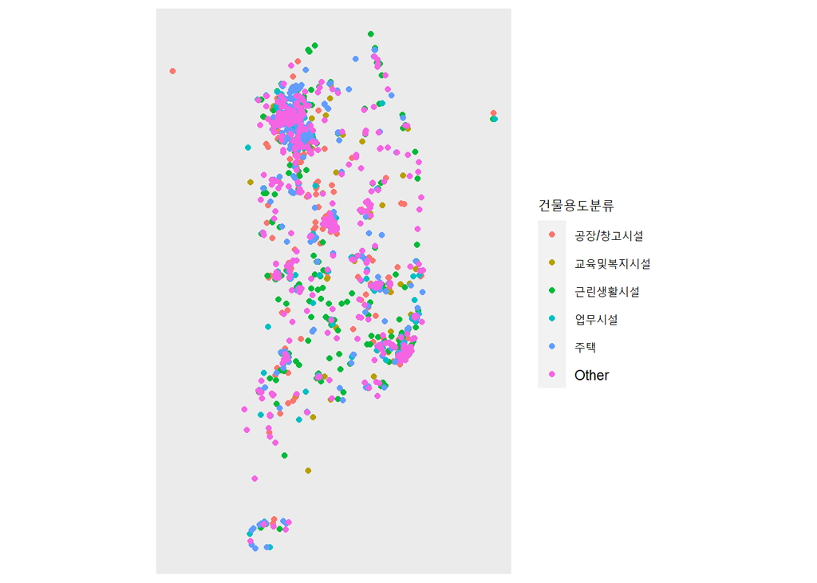

```r
loc_gps_sf %>%
  mutate(건물용도분류 = fct_lump(건물용도분류, 5)) %>%
  ggplot(aes(color=건물용도분류)) +
    geom_sf()
```

[^1]: [토리홀릭, “RStudio 주소와 자표 - 위도, 경도 좌표 변환하기”](https://m.blog.naver.com/hss2864/221645763282)

데이터 과학자 [이광춘](https://github.com/statkclee/) 저작

*kwangchun.lee.7@gmail.com*